# Wine Quality Data Analysis

*- By Maithili Desai*

## Introduction

- In this case study, I will perform the entire data analysis process to investigate a dataset on wine quality.
- I am going to investigate this dataset on physicochemical properties and quality ratings of red and white wine samples.
- Here, I'll will be analysing two datasets, one, on red wine samples and the other on white wine samples from the north of Portugal.
- Each wine sample comes with a quality rating from one to ten and results from several physicochemical tests.
- Due to privacy and logistic issues, only data on these physicochemical properties and quality ratings are available *(e.g. there is no data about grape types, wine brand, wine selling price, etc.)*

## Questions to be answered:

1. Is a certain type of wine associated with higher quality?
2. What level of acidity receives the highest average rating?
3. Do wines with higher alcoholic content receive better ratings?
4. Do sweeter wines receive better ratings?
5. Is there a mapping between quality rating and type of wine?

## Dataset Overview

- **Datasets**: `winequality-red.csv` and `winequality-white.csv` which can be downloaded from [here](https://archive.ics.uci.edu/ml/datasets/Wine+Quality)
- There are total **12 attributes** and **4898 observations** in each dataset
- **Input Variables** *(based on physicochemical tests)*:
  1. fixed acidity
  2. volatile acidity
  3. citric acid
  4. residual sugar
  5. chlorides
  6. free sulfur dioxide
  7. total sulfur dioxide
  8. density
  9. pH
  10. sulphates
  11. alcohol
- **Output variable** *(based on sensory data)*:
  1. quality- score between 0 and 10 (median of at least 3 evaluations made by the wine experts)

## Wine Quality Data Set from UCI Machine Learning Lab

There are two datasets that provide information on samples of red and white variants of the Portuguese "Vinho Verde" wine. Each sample of wine was rated for quality by wine experts and examined with physicochemical tests.

```python
# Importing library
import pandas as pd

# Loading red wine dataset
df_a = pd.read_csv('winequality-red.csv',sep=';')
df_a.head()
```

|  | fixed acidity | volatile acidity | citric acid | residual sugar | chlorides | free sulfur dioxide | total sulfur dioxide | density | pH | sulphates | alcohol | quality |
| --- | --- | --- | --- | --- | --- | --- | --- | --- | --- | --- | --- | --- |
| 0 | 7.4 | 0.70 | 0.00 | 1.9 | 0.076 | 11.0 | 34.0 | 0.9978 | 3.51 | 0.56 | 9.4 | 5 |
| 1 | 7.8 | 0.88 | 0.00 | 2.6 | 0.098 | 25.0 | 67.0 | 0.9968 | 3.20 | 0.68 | 9.8 | 5 |
| 2 | 7.8 | 0.76 | 0.04 | 2.3 | 0.092 | 15.0 | 54.0 | 0.9970 | 3.26 | 0.65 | 9.8 | 5 |
| 3 | 11.2 | 0.28 | 0.56 | 1.9 | 0.075 | 17.0 | 60.0 | 0.9980 | 3.16 | 0.58 | 9.8 | 6 |
| 4 | 7.4 | 0.70 | 0.00 | 1.9 | 0.076 | 11.0 | 34.0 | 0.9978 | 3.51 | 0.56 | 9.4 | 5 |

```python
# Loading white wine dataset
df_b = pd.read_csv('winequality-white.csv',sep=';')
df_b.head()
```

|  | fixed acidity | volatile acidity | citric acid | residual sugar | chlorides | free sulfur dioxide | total sulfur dioxide | density | pH | sulphates | alcohol | quality |
| --- | --- | --- | --- | --- | --- | --- | --- | --- | --- | --- | --- | --- |
| 0 | 7.0 | 0.27 | 0.36 | 20.7 | 0.045 | 45.0 | 170.0 | 1.0010 | 3.00 | 0.45 | 8.8 | 6 |
| 1 | 6.3 | 0.30 | 0.34 | 1.6 | 0.049 | 14.0 | 132.0 | 0.9940 | 3.30 | 0.49 | 9.5 | 6 |
| 2 | 8.1 | 0.28 | 0.40 | 6.9 | 0.050 | 30.0 | 97.0 | 0.9951 | 3.26 | 0.44 | 10.1 | 6 |
| 3 | 7.2 | 0.23 | 0.32 | 8.5 | 0.058 | 47.0 | 186.0 | 0.9956 | 3.19 | 0.40 | 9.9 | 6 |
| 4 | 7.2 | 0.23 | 0.32 | 8.5 | 0.058 | 47.0 | 186.0 | 0.9956 | 3.19 | 0.40 | 9.9 | 6 |

# Assessing Data

In this section, with the help of Pandas library I have explored the following characteristics of the dataset:

# Appending Data

I'll combine the red and white datasets to make my analysis more efficient. This can be done in two steps:

```python
# Append dataframes
wine_df = df_a.append(df_b)

# View dataframe to check success
wine_df.head()
```

[output not shown]

# Exploring with Visuals

In this section I will perform exploratory data analysis on newly combined dataframe. The visuals created in this section will help answer these questions:

**Insights:**

### Q1. Is a certain type of wine associated with higher quality?

For this question, I will compare the average quality of red wine with the average quality of white wine with groupby. To do this I will group by color and then find the mean quality of each group.

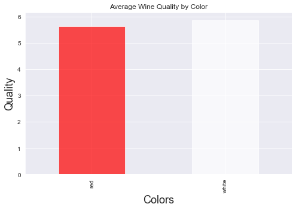

```python
#Load matplotlib and seaborn
import matplotlib.pyplot as plt
import seaborn as sns
%matplotlib inline
sns.set_style('darkgrid')

# Find the mean quality of each wine type (red and white) with groupby
color_means = df.groupby('color')['quality'].mean()

#Plot
colors = ['red','white']
plt.figure(figsize=[8,5])
color_means.plot(kind='bar', title='Average Wine Quality by Color',color=colors, alpha=.7)
plt.xlabel('Colors',fontsize=18)
plt.ylabel('Quality',fontsize=18);
```

**Thus, the mean quality of red wine is less than that of white wine**

Although, this plot depicts that the white wine samples have slightly higher average ratings, it will be nice to get more details on where that's coming from. *(Drawing Conclusions Section)*

### Q2. What level of acidity receives the highest average rating?

pH is a quantitative variable without clear categories. I'll answer this question by creating a categorical variable from a quantitative variable (`pH`) to create my own categories using pandas' `cut` function to "cut" data in groups.

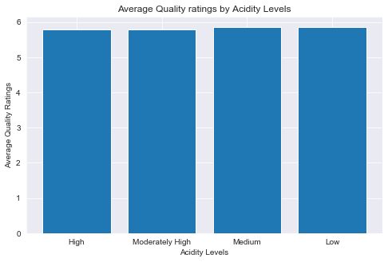

```python
# Order
loc_acid= [1,2,3,4]

# Height
heights_acid= acidity_level_quality_means

# Plot
plt.figure(figsize=[8,5])
plt.bar(loc_acid, heights_acid, tick_label=['High','Moderately High','Medium','Low'])
#labels = acidity_level_quality_means.index.str.replace('_', ' ').str.title()
plt.title('Average Quality ratings by Acidity Levels')
plt.xlabel('Acidity Levels')
plt.ylabel('Average Quality Ratings');
```

**Thus, low level of acidity receives the highest mean quality rating**

### Q3. Do wines with higher alcoholic content receive better ratings?

To answer this question, I'll use query to create two groups of wine samples:

1. Low alcohol (samples with an alcohol content less than the median)
2. High alcohol (samples with an alcohol content greater than or equal to the median)

Then, find the mean quality rating of each group.

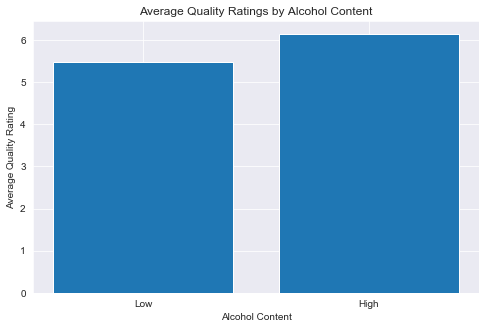

```python
# Create a bar chart with proper labels
locations = [1, 2]
heights = [mean_quality_low, mean_quality_high]
labels = ['Low', 'High']

plt.figure(figsize=[8,5])

plt.bar(locations, heights, tick_label=labels)
plt.title('Average Quality Ratings by Alcohol Content')
plt.xlabel('Alcohol Content')
plt.ylabel('Average Quality Rating');
```

**Thus, wines with higher alcoholic content generally receive better ratings**

### Q4. Do sweeter wines receive better ratings?

Similar to the question above, here I'll use the median to split the samples into two groups by residual sugar and find the mean quality rating of each group.

1. Low sugar (samples with sugar content less than the median)
2. High sugar (samples with sugar content greater than or equal to the median)

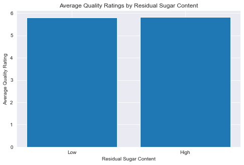

```python
# Create a bar chart with proper labels
locations = [1, 2]
heights = [mean_quality_low_sugar, mean_quality_high_sugar]
labels = ['Low', 'High']

plt.figure(figsize=[8,5])

plt.bar(locations, heights, tick_label=labels)
plt.title('Average Quality Ratings by Residual Sugar Content')
plt.xlabel('Residual Sugar Content')
plt.ylabel('Average Quality Rating');
```

## Q5. Is there a mapping between quality rating and type of wine?

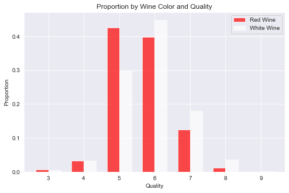

```python
# plot bars
plt.figure(figsize=[8,5])
red_bars = plt.bar(ind, red_proportions, width, color='r', alpha=.7, label='Red Wine')
white_bars = plt.bar(ind + width, white_proportions, width, color='w', alpha=.7, label='White Wine')

# title and labels
plt.ylabel('Proportion')
plt.xlabel('Quality')
plt.title('Proportion by Wine Color and Quality')
locations = ind + width / 2  # xtick locations
labels = ['3', '4', '5', '6', '7', '8', '9']  # xtick labels
plt.xticks(locations, labels)


# legend
plt.legend();
```

Matplotlib gives much more control over visualizations. This plot further confirms:

- Lower ratings (3, 4 and 5): red samples show higher proportions
- Higher ratings (6, 7, 8 and 9): white samples have higher proportions

Thus, I have completed a full analysis on a data set with the fundamentals of python's core packages for data analysis.

## Conclusion and Insights:

**1. Is a certain type of wine associated with higher quality?**

```
   - The mean quality of red wine is less than that of white wine
```

**2. What level of acidity receives the highest average rating?**

```
   - Low level of acidity receives the highest mean quality rating
```

**3. Do wines with higher alcoholic content receive better ratings?**

```
   - Yes, wines with higher alcoholic content generally receive better ratings
```

**4. Do sweeter wines receive better ratings?**

[output not shown]

**5. Is there a mapping between a particular range of quality ratings and type of wine?**

```
   - Yes. The lower ratings from 3-5 had more red samples than white. Whereas, as the quality ratings increased, white wines dominated more than red wine in the dataset.
```